# 01-Visualization

Imports

```python
import pandas as pd
import matplotlib.pyplot as plt
import seaborn as sns
```

Carregar dataframe e visualizar

```python
df = pd.read_csv('../data/brute/df_full.csv')
print(df.shape)
print(df.info()) # Sem valores nulos
df.head()
```

```
(66540, 15)
<class 'pandas.core.frame.DataFrame'>
RangeIndex: 66540 entries, 0 to 66539
Data columns (total 15 columns):
 #   Column       Non-Null Count  Dtype
---  ------       --------------  -----
 0   Timestamp    66540 non-null  object
 1   S1_1         66540 non-null  float64
 2   S1_2         66540 non-null  float64
 3   S1_3         66540 non-null  float64
 4   S1_4         66540 non-null  float64
 5   S1_5         66540 non-null  float64
 6   S1_6         66540 non-null  float64
 7   S2_1         66540 non-null  float64
 8   S2_2         66540 non-null  float64
 9   S3_1         66540 non-null  float64
 10  S3_2         66540 non-null  float64
 11  S4_1         66540 non-null  float64
 12  S4_2         66540 non-null  float64
 13  Nivel_agua   66540 non-null  float64
 14  Nivel_total  66540 non-null  float64
dtypes: float64(14), object(1)
memory usage: 7.6+ MB
None
```

|  | Timestamp | S1_1 | S1_2 | S1_3 | S1_4 | S1_5 | S1_6 | S2_1 | S2_2 | S3_1 | S3_2 | S4_1 | S4_2 | Nivel_agua | Nivel_total |
| --- | --- | --- | --- | --- | --- | --- | --- | --- | --- | --- | --- | --- | --- | --- | --- |
| 0 | 28/03/2022 16:30:26.57745 | 1524.09200 | 1524.68570 | 1530.24903 | 1538.64225 | 1552.56175 | 1553.28008 | 1530.97697 | 1539.25600 | 1544.74917 | 1550.44190 | 1545.14272 | 1559.75003 | 257.0 | 257.0 |
| 1 | 28/03/2022 16:30:27.07745 | 1524.09059 | 1524.68520 | 1530.24959 | 1538.64228 | 1552.56153 | 1553.28018 | 1530.97808 | 1539.25592 | 1544.75001 | 1550.44253 | 1545.14266 | 1559.75004 | 257.0 | 257.0 |
| 2 | 28/03/2022 16:30:27.57745 | 1524.09108 | 1524.68440 | 1530.24883 | 1538.64254 | 1552.56085 | 1553.28046 | 1530.97912 | 1539.25621 | 1544.74792 | 1550.44108 | 1545.14126 | 1559.75247 | 257.0 | 257.0 |
| 3 | 28/03/2022 16:30:28.07745 | 1524.09161 | 1524.68487 | 1530.24907 | 1538.64199 | 1552.56206 | 1553.28030 | 1530.97905 | 1539.25607 | 1544.74877 | 1550.44254 | 1545.14166 | 1559.75295 | 257.0 | 257.0 |
| 4 | 28/03/2022 16:30:28.57745 | 1524.09070 | 1524.68511 | 1530.24922 | 1538.64187 | 1552.56135 | 1553.27996 | 1530.97980 | 1539.25519 | 1544.74875 | 1550.44097 | 1545.14139 | 1559.74994 | 257.0 | 257.0 |

```python
df.describe()
```

|  | S1_1 | S1_2 | S1_3 | S1_4 | S1_5 | S1_6 | S2_1 | S2_2 | S3_1 | S3_2 | S4_1 | S4_2 | Nivel_agua | Nivel_total |
| --- | --- | --- | --- | --- | --- | --- | --- | --- | --- | --- | --- | --- | --- | --- |
| count | 66540.000000 | 66540.000000 | 66540.000000 | 66540.000000 | 66540.000000 | 66540.000000 | 66540.000000 | 66540.000000 | 66540.000000 | 66540.000000 | 66540.000000 | 66540.000000 | 66540.000000 | 66540.000000 |
| mean | 1524.134287 | 1524.730478 | 1530.291499 | 1538.683594 | 1552.585198 | 1553.321983 | 1531.088692 | 1539.395152 | 1544.837456 | 1550.519120 | 1545.308524 | 1558.082188 | 1245.555020 | 1596.034836 |
| std | 0.054754 | 0.055615 | 0.056080 | 0.065582 | 0.060931 | 0.076920 | 0.166813 | 0.158077 | 0.110521 | 0.150314 | 0.151640 | 4.585039 | 734.131379 | 745.587549 |
| min | 1523.876580 | 1524.632450 | 1530.188590 | 1538.571820 | 1552.386530 | 1553.097760 | 1530.652050 | 1539.029490 | 1544.519990 | 1550.201170 | 1545.027500 | 1545.204630 | 109.000000 | 109.000000 |
| 25% | 1524.089350 | 1524.688170 | 1530.248818 | 1538.641880 | 1552.556660 | 1553.277568 | 1531.038010 | 1539.360270 | 1544.746688 | 1550.397470 | 1545.222540 | 1559.539840 | 791.000000 | 1287.000000 |
| 50% | 1524.128870 | 1524.720210 | 1530.281990 | 1538.672615 | 1552.571130 | 1553.290640 | 1531.080450 | 1539.386375 | 1544.843610 | 1550.510815 | 1545.287020 | 1559.679345 | 1219.000000 | 1656.000000 |
| 75% | 1524.160922 | 1524.765310 | 1530.314970 | 1538.705990 | 1552.584570 | 1553.333610 | 1531.185390 | 1539.425900 | 1544.924012 | 1550.622420 | 1545.383850 | 1559.762980 | 1880.000000 | 2188.000000 |
| max | 1524.299000 | 1524.905580 | 1530.464740 | 1538.917920 | 1552.823080 | 1553.571740 | 1531.635210 | 1540.003880 | 1545.096100 | 1550.912600 | 1545.873190 | 1560.415660 | 2804.000000 | 2804.000000 |

Sensor S4_2 tem grande desvio padrão, visualização abaixo para entender melhor

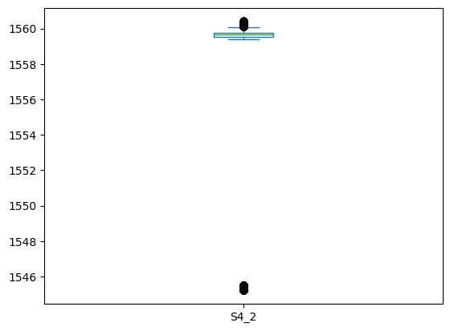

```python
df['S4_2'].plot(kind='box')
plt.show()
```

Possívelmente sensor S4_2 está com defeito, provavelmente é melhor ignora-lo nos próximos passos

```python
print(df.isnull().sum())
print(df.duplicated().sum())
#Sem valores nulos ou duplicados
```

```
Timestamp      0
S1_1           0
S1_2           0
S1_3           0
S1_4           0
S1_5           0
S1_6           0
S2_1           0
S2_2           0
S3_1           0
S3_2           0
S4_1           0
S4_2           0
Nivel_agua     0
Nivel_total    0
dtype: int64
0
```

Histograma de todos os sensores incluindo o sensor com "defeito"

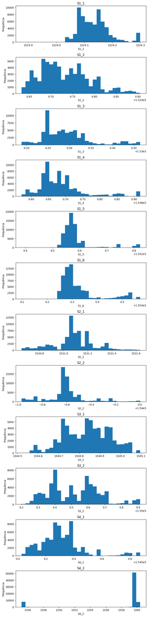

```python
num_sensors = 12
sensor_cols = [col for col in df.columns if col.startswith('S')]
fig, axes = plt.subplots(num_sensors, 1, figsize=(8, 33))
for i, col in enumerate(sensor_cols):
    df[col].plot(kind='hist', bins=30, ax=axes[i], title=col)
    axes[i].set_xlabel(col)
    axes[i].set_ylabel('Frequência')
plt.tight_layout()
plt.show()
```

Podemos ver claramente que o sensor S4_2 deve ser removido

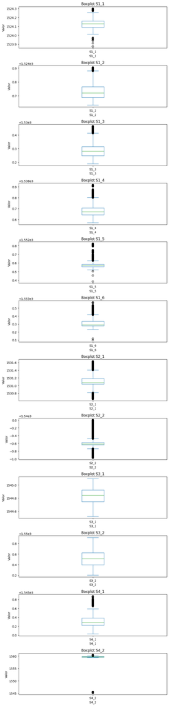

```python
num_sensors = 12
sensor_cols = [col for col in df.columns if col.startswith('S')]
fig, axes = plt.subplots(num_sensors, 1, figsize=(8, 33))
for i, col in enumerate(sensor_cols):
    df[col].plot(kind='box', ax=axes[i], title=f'Boxplot {col}')
    axes[i].set_xlabel(col)
    axes[i].set_ylabel('Valor')
plt.tight_layout()
plt.show()
```

Vemos que temos diversos valores outliers nos sensores, remove-los pode não ser a melhor opção pois perderiamos muitos dados que podem ser relevantes se ajustados corretamente

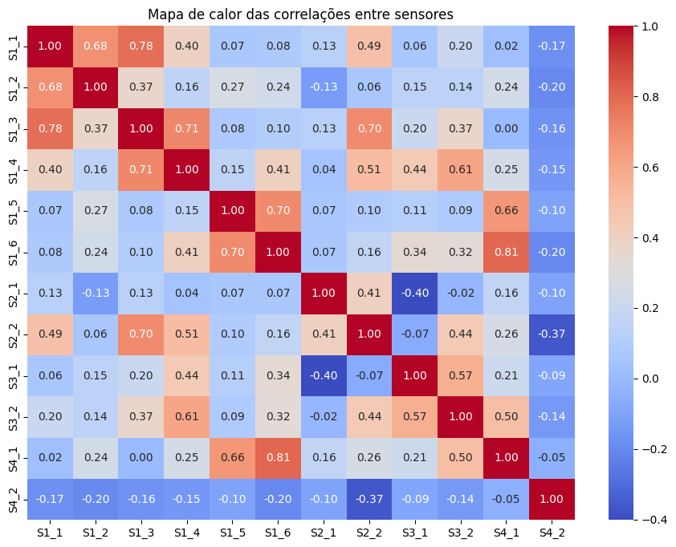

```python
corr = df[sensor_cols].corr()
plt.figure(figsize=(11, 8))
sns.heatmap(corr, annot=True, cmap='coolwarm', fmt='.2f')
plt.title('Mapa de calor das correlações entre sensores')
plt.show()
```

```
O 'Timestamp' já é o índice do DataFrame. Nenhuma ação necessária.
```

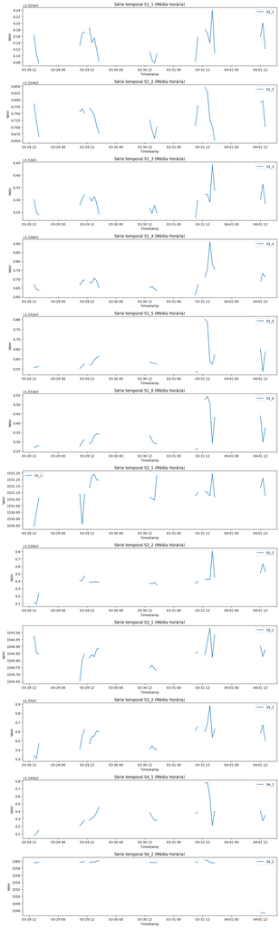

```python
# Verifica se 'Timestamp' é uma coluna antes de fazer qualquer coisa
if 'Timestamp' in df.columns:
    print("Convertendo a coluna 'Timestamp' e definindo como índice...")
    # 1. Garanta que a coluna de tempo é do tipo datetime
    df['Timestamp'] = pd.to_datetime(df['Timestamp'])
    # 2. Defina o Timestamp como índice
    df.set_index('Timestamp', inplace=True)
else:
    print("O 'Timestamp' já é o índice do DataFrame. Nenhuma ação necessária.")
# 3. Reamostre os dados. 'H' = por hora. Você pode usar 'D' para dia, 'T' para minuto, etc.
df_reamostrado = df.resample('h').mean() # Pega a média de cada hora

# 4. Plote os dados reamostrados (note que o eixo X já é o índice)
fig, axes = plt.subplots(num_sensors, 1, figsize=(12, 40))
for i, col in enumerate(sensor_cols):
    axes[i].plot(df_reamostrado.index, df_reamostrado[col], label=col)
    axes[i].set_title(f'Série temporal {col} (Média Horária)')
    axes[i].set_xlabel('Timestamp')
    axes[i].set_ylabel('Valor')
    axes[i].legend()

plt.tight_layout()
plt.show()
```

Podemos ver que os sensores oscilam em horários específicos, podendo ser removidos nos quais eles não mudam

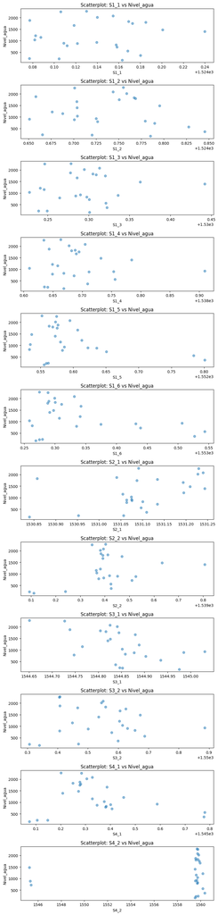

```python
fig, axes_scatter = plt.subplots(num_sensors, 1, figsize=(8, 33))
for idx, sensor in enumerate(sensor_cols):
    axes_scatter[idx].scatter(df_reamostrado[sensor], df_reamostrado['Nivel_agua'], alpha=0.5)
    axes_scatter[idx].set_xlabel(sensor)
    axes_scatter[idx].set_ylabel('Nivel_agua')
    axes_scatter[idx].set_title(f'Scatterplot: {sensor} vs Nivel_agua')
plt.tight_layout()
plt.show()
```

Podemos ver que os pontos são dispersos em formato de "nuvem", sendo assim, algoritmos com funcoes lineares como a regreção linear terá dificuldade de convergir. É indicado utilizar algoritmos não-lineares mais complexos

### RESUMO FINAL

Após visualização, temos algumas informações uteis para serem utilizadas na próxima etapa de tratamento. O dataset está razoavelmente limpo, sem valores nulos, evitando este tratamento. Entre os tratamentos que deverão ser analisados, está a remoção do sensor S4_2, este estando claramente com defeito, resultando em valores sem nexo que podem atrapalhar o modelo final.

Os demais sensores, temos alguns outliers que deverão ser tratados: Os sensores S3_X estão corretos, sem grandes outliers a serem tratados. Os demais sensores seguem um padrão de quantidade, mas com uma quantidade considerável. É interessante trata-los e não remove-los afim de não perder uma quantidade alta de dados.

Em relação a análise temporal em relação ao nivel de água, podemos ver que a alteração ocorre em horários específicos. Provavelmente a válvula que controla a entrada de novos liquidos deve ser ativadas em momentos específicos, seria interessante encontrar esses períodos e remover os outros em que não existe alteração , pois serão valores repetidos.

Em relação à dispersão dos dados, é notavel que eles não seguem uma reta linear, sendo assim, é necessário usar um algoritmo mais complexo, para poder se adequar a estas "nuvens" em que os dados estão.